# OGM 2022 Materials - SNA

### Calculate and add degree and betweenness centrality measures

```r
degree2 <- degree(network2)
betweenness2 <- betweenness(network2)
```

```r
network2 <- network2 %>%
  delete.vertices(which(degree2<2))
```

Now we can visualize this, as a somewhat more meaningful network. To highlight connections, we can also add tie strength (edge/link weights):

### Calculate and visualize relationship tie strength (edge weight)

```
## Using `stress` as default layout
```

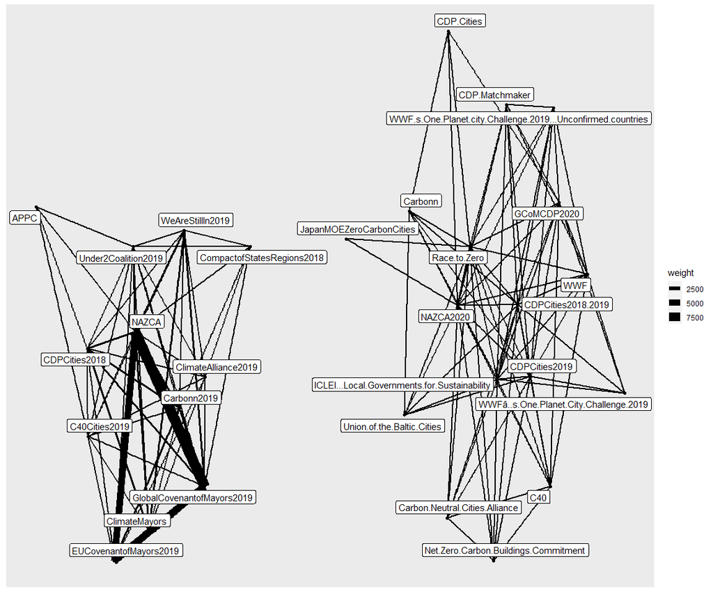

```r
ggraph(network2) +
  geom_node_point() +
  geom_edge_link(aes(edge_width=weight)) +
  geom_node_label(aes(label=name), repel = T)
```

# **Discussions**

- What are the key features of these networks, in terms of structure, positions, relations?
- If you were leading a Copenhagen Municipality Climate plan, and you wanted to, say, find the most climate-progressive organisations to spar with, or the key initiatives to join, how would you do that?
- In other words, who are the key organisations and initiatives in the network to lobby/contact/connect with, based on centrality measures and network structure, and why?